# Trabajo final. Geoinformática 2019-2020

##### Fernanda Gaytán Camarillo y Janet Milanez Figueroa

### Exploración de datos

En este Notebook haremos la exploración de los datos con los que vamos a hacer nuestro ejercicio. Nuestra página presenta datos sobre contaminantes atmosféricos y el objetivo del trabajo final es detectar hotspots de contaminación en la Zona Metropolitana del Valle de México por medio de un análisis de autocorrelación espacial, así como visualizar la distribución de las Fuentes Fijas de contaminantes y realizar con ellas un análisis de patrones puntuales que determine si existe algún patrón de agregación espacial.  
Pero antes de poder realizar nuestros análisis debemos ver con qué datos contamos, evaluar las medidas de tendencia central de las variables que usaremos y familiarizarnos con la información antes de su análisis  
Los presentes datos fueron obtenidos del [Inventario de Emisiones 2016](http://www.aire.cdmx.gob.mx/default.php?opc=%27aKBhnmU=%27&opcion=bg==) de la página de Calidad de Aire de SEDEMA.

```python
#Estas son las librerías que nos permitirán explorar la información que tenemos en formato .csv, a modo de dataframes
import pandas as pd
import numpy as np
```

```python
#Importamos los datos de emisiones y las claves de municipios
df = pd.read_csv("C:/Users/fersh/Google Drive (fgaytan@centrogeo.edu.mx)/Tercer Cuatrimestre/Fundamentos de Geoinformática/Trabajo_final/emisiones.csv")
mun = pd.read_csv("C:/Users/fersh/Google Drive (fgaytan@centrogeo.edu.mx)/Tercer Cuatrimestre/Fundamentos de Geoinformática/Trabajo_final/cves_mun.csv")
```

```python
#Esta es la base de datos de las emisiones de los contaminantes que seleccionamos:
#Particulas suspendidas: Material particulado de menos de 10 y de menos de 2.5 micrómetros (PM10 y PM25, respectivamente)
#Precursores de ozono: Óxidos de Nitrógeno (NOX) y Compuestos Orgánicos Volátiles (COV)
#Cabe resaltar que los valores no se encunetran en las mismas unidades de medición
df
```

|  | CVE_GEO | DEL_MUN | PM10 | PM25 | NOX | COV |
| --- | --- | --- | --- | --- | --- | --- |
| 0 | 15002 | Acolman | 68.653593 | 17.777834 | 47.334930 | 95.577450 |
| 1 | 9010 | Alvaro Obregon | 2.568828 | 1.713469 | 19.052067 | 520.790620 |
| 2 | 15009 | Amecameca | 81.311355 | 20.421787 | 47.396392 | 21.686285 |
| 3 | 15010 | Apaxco | 44.923059 | 11.103629 | 26.922286 | 35.463659 |
| 4 | 15011 | Atenco | 33.553189 | 8.642810 | 22.000338 | 28.519336 |
| ... | ... | ... | ... | ... | ... | ... |
| 71 | 15122 | Valle de Chalco Solidaridad | 13.474770 | 3.948106 | 16.637685 | 113.673148 |
| 72 | 9017 | Venustiano Carranza | 1.028564 | 1.028564 | 13.533739 | 387.788454 |
| 73 | 15112 | Villa del Carbon | 101.836127 | 25.434268 | 60.156419 | 24.122761 |
| 74 | 9013 | Xochimilco | 17.384947 | 5.998480 | 22.699363 | 312.093741 |
| 75 | 15120 | Zumpango | 210.036975 | 54.024509 | 128.851633 | 77.690105 |

76 rows × 6 columns

```python
#Nos permitirá agregarle a la base de emisiones la clave de entidad (CVE_ENT)
mun
```

|  | NOM_MUN | CVE_ENT | CVE_MUN | CVE_GEO |
| --- | --- | --- | --- | --- |
| 0 | Acolman | 15 | 2 | 15002 |
| 1 | Alvaro Obregon | 9 | 10 | 9010 |
| 2 | Amecameca | 15 | 9 | 15009 |
| 3 | Apaxco | 15 | 10 | 15010 |
| 4 | Atenco | 15 | 11 | 15011 |
| ... | ... | ... | ... | ... |
| 71 | Valle de Chalco Solidaridad | 15 | 122 | 15122 |
| 72 | Venustiano Carranza | 9 | 17 | 9017 |
| 73 | Villa del Carbon | 15 | 112 | 15112 |
| 74 | Xochimilco | 9 | 13 | 9013 |
| 75 | Zumpango | 15 | 120 | 15120 |

76 rows × 4 columns

```python
#Utilizando la variable CVE_GEO unimos los dataframes para tener en el df de las emisiones la CVE_ENT
df = df.join(mun.set_index('CVE_GEO'), on='CVE_GEO')
```

```python
df
```

|  | CVE_GEO | DEL_MUN | PM10 | PM25 | NOX | COV | NOM_MUN | CVE_ENT | CVE_MUN |
| --- | --- | --- | --- | --- | --- | --- | --- | --- | --- |
| 0 | 15002 | Acolman | 68.653593 | 17.777834 | 47.334930 | 95.577450 | Acolman | 15 | 2 |
| 1 | 9010 | Alvaro Obregon | 2.568828 | 1.713469 | 19.052067 | 520.790620 | Alvaro Obregon | 9 | 10 |
| 2 | 15009 | Amecameca | 81.311355 | 20.421787 | 47.396392 | 21.686285 | Amecameca | 15 | 9 |
| 3 | 15010 | Apaxco | 44.923059 | 11.103629 | 26.922286 | 35.463659 | Apaxco | 15 | 10 |
| 4 | 15011 | Atenco | 33.553189 | 8.642810 | 22.000338 | 28.519336 | Atenco | 15 | 11 |
| ... | ... | ... | ... | ... | ... | ... | ... | ... | ... |
| 71 | 15122 | Valle de Chalco Solidaridad | 13.474770 | 3.948106 | 16.637685 | 113.673148 | Valle de Chalco Solidaridad | 15 | 122 |
| 72 | 9017 | Venustiano Carranza | 1.028564 | 1.028564 | 13.533739 | 387.788454 | Venustiano Carranza | 9 | 17 |
| 73 | 15112 | Villa del Carbon | 101.836127 | 25.434268 | 60.156419 | 24.122761 | Villa del Carbon | 15 | 112 |
| 74 | 9013 | Xochimilco | 17.384947 | 5.998480 | 22.699363 | 312.093741 | Xochimilco | 9 | 13 |
| 75 | 15120 | Zumpango | 210.036975 | 54.024509 | 128.851633 | 77.690105 | Zumpango | 15 | 120 |

76 rows × 9 columns

#### ¿Por qué la unión?

Con la CVE_ENT vamos a poder explorar la información por entidades.

```python
#¿Qué entidades tiene nuestra base de datos?
df['CVE_ENT'].unique()
```

```
array([15,  9, 13], dtype=int64)
```

#### Entidades de nuestra base de datos

Tenemos en esta base tres Estados de la República Mexicana: CDMX(CVE_ENT:9), Estado de México (CVE_ENT:15) e Hidalgo (CVE_ENT:13). Entonces lo primero es ver la cantidad de contaminantes que aportan cada una y eso lo haremos con un gráfico de barras.

```python
#Librería que necesito para poder graficar
import matplotlib.pyplot as plt
import matplotlib.image as mpimg
import seaborn as sns
```

```python
from IPython.core.interactiveshell import InteractiveShell
InteractiveShell.ast_node__interactivity ="all"
%matplotlib inline
```

```python
#Para poder visualizar la distribución de los 4 tipos de contaminantes en las 3 entidades de la ZMVM
by_ent= df.pivot_table(index='CVE_ENT', values=('PM10','PM25', 'NOX', 'COV'), aggfunc=np.sum)
by_ent
```

| CVE_ENT | COV | NOX | PM10 | PM25 |
| --- | --- | --- | --- | --- |
| 9 | 11179.402874 | 522.298609 | 208.888774 | 81.797075 |
| 13 | 329.295670 | 177.224814 | 53.948401 | 22.579518 |
| 15 | 10145.035131 | 2539.302104 | 2876.504407 | 776.332512 |

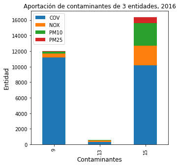

```python
chart = by_ent.plot(kind='bar', stacked= True, title = 'Aportación de contaminantes de 3 entidades, 2016', figsize=(5,5));
chart.set_xlabel("Contaminantes", fontsize=12);
chart.set_ylabel("Entidad", fontsize=12);
```

#### ¿Qué vemos en nuestra gráfica?

[figure not shown]

La aportación del Estado de Hidalgo es muy baja en comparación a el Estado de México y de la CDMX. Bueno, esto es porque el único municipio de Hidalgo que forma parte de la ZMVM es Tizayuca, y es considerado así porque está literalmente rodeado por municipios del estado de México:

Podemos ver también que en la emisión de COV la CDMX tiene un mayor aporte, pero en lo que respecta a los otros 3 contaminantes es evidentemente superada por el Estado de México. Sin embargo, como ya habíamos mencionado, los contaminantes se miden de manera diferente, entonces para poder visualizar bien la diferencia de cada uno, es necesario graficarlos por separado:

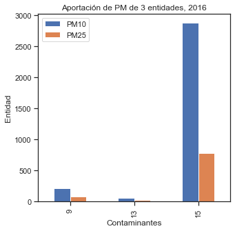

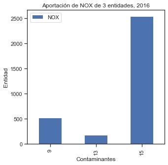

```python
by_ent= df.pivot_table(index='CVE_ENT', values=('PM10','PM25'), aggfunc=np.sum)
chart = by_ent.plot(kind='bar', stacked= False, title = 'Aportación de PM de 3 entidades, 2016', figsize=(5,5));
chart.set_xlabel("Contaminantes", fontsize=12);
chart.set_ylabel("Entidad", fontsize=12);
by_ent2= df.pivot_table(index='CVE_ENT', values=('NOX'), aggfunc=np.sum)
chart = by_ent2.plot(kind='bar', stacked= False, title = 'Aportación de NOX de 3 entidades, 2016', figsize=(5,5));
chart.set_xlabel("Contaminantes", fontsize=12);
chart.set_ylabel("Entidad", fontsize=12);
```

### Explicación:

Una vez más observamos que la aportación de Hidalgo es mínima, ya explicamos la razón de ello. Con respecto a la CDMX y a EDOMEX, el único contaminante en el que la CDMX aporta más que el EDOMEX es en los Compuestos Orgánicos Volátiles. En el caso del Material Particulado el EDOMEX supera por mucho a la CDMX. y esto puede deberse a que hay muchas industrias en el Estado de México. En el caso del Óxido de Nitrógeno, en donde también el EDOMEX supera de manera importante a la CDMX, puede ser que el aforo vehicular predominante en el Estado de México son tractocamiones y demás transportes grandes

### Industrias en la CDMX:

Ahora, de acuerdo al Inventario de Emisiones de la Ciudad de México, 2016, las alcaldías con más industrias en la CDMX son: Azcapotzalco, Iztacalco, Iztapalapa. Las industrias son emisoras puntuales de contaminantes, por lo que los contaminantes que más emiten son: PM10 y PM25; y en menor cantidad COV y NOX. Para comprobar que eso es cierto hay que filtrar nuestra tabla dejando solo la CDMX y las emisiones de PM10 y PM2.5, y obtener nuestro gráfico de barras de eso:

```python
#Filtramos utilizando CVE_ENT y al hacer la pivot table solo pedimos las variables de PM
mayor_em = df[df.CVE_ENT.isin([9])]
by_alc= mayor_em.pivot_table(index=['DEL_MUN'], values=('PM10','PM25'))
```

```python
by_alc
```

| DEL_MUN | PM10 | PM25 |
| --- | --- | --- |
| Alvaro Obregon | 2.568828 | 1.713469 |
| Azcapotzalco | 3.766496 | 3.674864 |
| Benito Juarez | 1.622323 | 1.622323 |
| Coyoacan | 1.595598 | 1.595598 |
| Cuajimalpa de Morelos | 1.705904 | 0.948241 |
| Cuauhtemoc | 3.091595 | 3.091595 |
| Gustavo A. Madero | 2.758618 | 2.694303 |
| Iztacalco | 2.449798 | 2.449798 |
| Iztapalapa | 5.868015 | 5.819095 |
| La Magdalena Contreras | 4.443986 | 1.425342 |
| Miguel Hidalgo | 3.047901 | 3.047901 |
| Milpa Alta | 66.377143 | 19.008736 |
| Tlahuac | 26.263613 | 7.661151 |
| Tlalpan | 64.915444 | 20.017613 |
| Venustiano Carranza | 1.028564 | 1.028564 |
| Xochimilco | 17.384947 | 5.998480 |

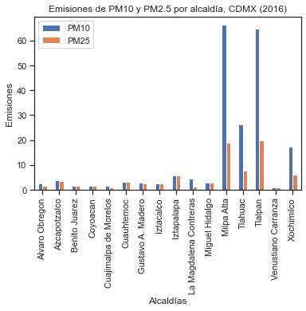

```python
chart = by_alc.plot(kind='bar', stacked= False, title = 'Emisiones de PM10 y PM2.5 por alcaldía, CDMX (2016)');
chart.set_xlabel("Alcaldías", fontsize=12);
chart.set_ylabel("Emisiones", fontsize=12);
```

#### ¿Khaá?

De acuerdo con nuestra gráfica, es mucho más el aporte de las alcaldías: **Milpa Alta, Tlalpan, Tlahuac y Xochimilco**.  
Esto tiene una explicación muy fácil, esta base de datos toma en cuenta todas las fuentes que emiten contaminantes, las cuales pueden ser:

1. Fuentes fijas: industrias
2. Fuentes naturales
3. Fuentes móviles: tranportes
4. Fuentes de área: negocios y actividades de la población

Por ello, no podemos realmente ver la aportación de las industrias, esta información la evaluaremos más adelante.  
Para que todo quede más claro, nos parece importante explicar un poco sobre cada contaminante. Veamos sus medidas de tendencia central (tomando en cuenta que no se miden con las mismas unidades) y veamos una gráfica de dispersión de los datos

```python
df.describe()
```

|  | CVE_GEO | PM10 | PM25 | NOX | COV | CVE_ENT | CVE_MUN |
| --- | --- | --- | --- | --- | --- | --- | --- |
| count | 76.000000 | 76.000000 | 76.000000 | 76.000000 | 76.000000 | 76.000000 | 76.000000 |
| mean | 13759.921053 | 41.307126 | 11.588278 | 42.616125 | 284.917548 | 13.710526 | 49.394737 |
| std | 2480.105330 | 47.191194 | 11.759593 | 40.482403 | 458.333721 | 2.459354 | 37.636181 |
| min | 9002.000000 | 0.695284 | 0.505166 | 1.744593 | 2.862001 | 9.000000 | 2.000000 |
| 25% | 15009.750000 | 6.192568 | 2.949477 | 13.788071 | 17.177235 | 15.000000 | 15.000000 |
| 50% | 15036.500000 | 23.885072 | 7.473415 | 29.913612 | 57.790273 | 15.000000 | 37.500000 |
| 75% | 15083.250000 | 59.825613 | 17.725138 | 56.122964 | 330.341417 | 15.000000 | 83.250000 |
| max | 15125.000000 | 210.036975 | 54.024509 | 180.337117 | 2147.670507 | 15.000000 | 125.000000 |

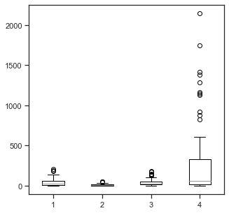

```python
#para ver las características de dispersión y simetría
em_por_cont = [df['PM10'],df['PM25'],df['NOX'],df['COV']]
plt.figure(1, figsize=(5,5))
plt.boxplot(em_por_cont)
plt.show;
```

### COV: Compuestos orgánicos volátiles

[figure not shown]

La variavle COV, que se refiere a los compuestos orgánicos vólatiles. Pero, **¿que son los compuestos orgánicos volátiles?**  
Son aquellos hidrocarburos que se volatilizan a temperatura ambiente. Participan en reacciones fotoquímicas en la atmósfera, generando ozono troposférico y aerosoles secundarios, perjudiciales para la salud de la población y de los ecosistemas. Y pueden provenir de diferentes fuentes:

```python
#Hay que ver los municipios o alcaldías son las que más aportan este tipo de contaminante:
by_cov = df.sort_values('COV', ascending= False)
by_cov
```

|  | CVE_GEO | DEL_MUN | PM10 | PM25 | NOX | COV | NOM_MUN | CVE_ENT | CVE_MUN |
| --- | --- | --- | --- | --- | --- | --- | --- | --- | --- |
| 33 | 9007 | Iztapalapa | 5.868015 | 5.819095 | 74.992745 | 2147.670507 | Iztapalapa | 9 | 7 |
| 66 | 15104 | Tlalnepantla de Baz | 14.980040 | 13.989695 | 180.337117 | 1748.411763 | Tlalnepantla de Baz | 15 | 104 |
| 24 | 15033 | Ecatepec de Morelos | 11.660016 | 11.173086 | 145.632886 | 1415.847123 | Ecatepec de Morelos | 15 | 33 |
| 9 | 9002 | Azcapotzalco | 3.766496 | 3.674864 | 48.198104 | 1381.010318 | Azcapotzalco | 9 | 2 |
| 42 | 15057 | Naucalpan de Juarez | 24.785013 | 13.919255 | 140.834595 | 1282.798806 | Naucalpan de Juarez | 15 | 57 |
| ... | ... | ... | ... | ... | ... | ... | ... | ... | ... |
| 25 | 15034 | Ecatzingo | 23.018138 | 5.922114 | 13.822091 | 5.063570 | Ecatzingo | 15 | 34 |
| 68 | 15125 | Tonanitla | 14.414195 | 3.695783 | 8.786627 | 4.444675 | Tonanitla | 15 | 125 |
| 35 | 15046 | Jilotzingo | 20.547992 | 5.014687 | 11.687424 | 4.013329 | Jilotzingo | 15 | 46 |
| 17 | 15022 | Cocotitlan | 11.799694 | 2.979543 | 6.842814 | 3.361618 | Cocotitlan | 15 | 22 |
| 30 | 15038 | Isidro Fabela | 17.440063 | 4.116144 | 9.277500 | 2.862001 | Isidro Fabela | 15 | 38 |

76 rows × 9 columns

```python
#Veamos el comportamiento de los primeros 5 con respecto a los otros contaminates:
#Decidí tomar los municipios con mayor producción de Ganado en Pie para ver las especies animales que más aportan
#a dicha producción en la serie de tiempo completa
em_COV = df[df.DEL_MUN.isin(['Iztapalapa','Tlalnepantla de Baz', 'Ecatepec de Morelos', 'Azcapotzalco', 'Naucalpan de Juarez'])]
g_COV= em_COV.pivot_table(index=['DEL_MUN'], values=('PM10','PM25', 'NOX'))
g_COV
```

| DEL_MUN | NOX | PM10 | PM25 |
| --- | --- | --- | --- |
| Azcapotzalco | 48.198104 | 3.766496 | 3.674864 |
| Ecatepec de Morelos | 145.632886 | 11.660016 | 11.173086 |
| Iztapalapa | 74.992745 | 5.868015 | 5.819095 |
| Naucalpan de Juarez | 140.834595 | 24.785013 | 13.919255 |
| Tlalnepantla de Baz | 180.337117 | 14.980040 | 13.989695 |

[figure not shown]

```python
#Vamos a poner una línea del color de cada contaminante para señalar
#el máximo detectado en las medidas de tendencia central
chart = g_COV.plot(kind='bar', stacked= False, title = 'Municipios mayores emisiones de COV (2016)');
plt.axhline(y=180,linewidth=1, color='navy');
plt.axhline(y=210,linewidth=1, color='orange');
plt.axhline(y=54,linewidth=1, color='green');
chart.set_xlabel("Municipios", fontsize=12);
chart.set_ylabel("Emisiones", fontsize=12);
```

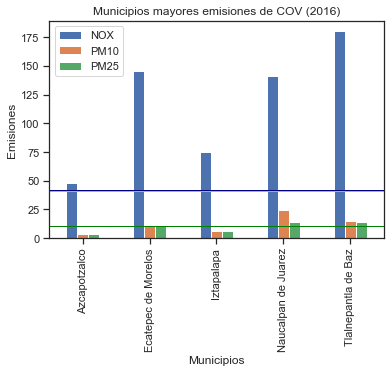

```python
#Vamos a poner una línea del color de cada contaminante para señalar
#los máximos detectados en las medidas de tendencia central
chart = g_COV.plot(kind='bar', stacked= False, title = 'Municipios mayores emisiones de COV (2016)');
plt.axhline(y=42,linewidth=1, color='navy');
plt.axhline(y=41,linewidth=1, color='orange');
plt.axhline(y=11,linewidth=1, color='green');
chart.set_xlabel("Municipios", fontsize=12);
chart.set_ylabel("Emisiones", fontsize=12);
```

### ¿Te dan ganas de ir a pasar un día al aire libre en esos municipios?

```python
from IPython.display import Image
Image(url='https://thumbs.gfycat.com/ImpressionableRigidCurlew-max-1mb.gif')
```

[figure not shown]

### PM10 y PM2.5: Material particulado

```python
#PM10
by_pm10 = df.sort_values('PM10', ascending= False)
by_pm10.head()
```

|  | CVE_GEO | DEL_MUN | PM10 | PM25 | NOX | COV | NOM_MUN | CVE_ENT | CVE_MUN |
| --- | --- | --- | --- | --- | --- | --- | --- | --- | --- |
| 75 | 15120 | Zumpango | 210.036975 | 54.024509 | 128.851633 | 77.690105 | Zumpango | 15 | 120 |
| 7 | 15016 | Axapusco | 194.553147 | 49.532049 | 108.295542 | 29.542789 | Axapusco | 15 | 16 |
| 53 | 15084 | Temascalapa | 183.849642 | 46.910556 | 107.847479 | 27.015092 | Temascalapa | 15 | 84 |
| 28 | 15036 | Hueypoxtla | 137.637327 | 35.251841 | 84.995443 | 29.081838 | Hueypoxtla | 15 | 36 |
| 47 | 15065 | Otumba | 136.783984 | 34.308415 | 67.897115 | 21.234120 | Otumba | 15 | 65 |

```python
#PM25
by_pm25 = df.sort_values('PM25', ascending= False)
by_pm25.head()
```

|  | CVE_GEO | DEL_MUN | PM10 | PM25 | NOX | COV | NOM_MUN | CVE_ENT | CVE_MUN |
| --- | --- | --- | --- | --- | --- | --- | --- | --- | --- |
| 75 | 15120 | Zumpango | 210.036975 | 54.024509 | 128.851633 | 77.690105 | Zumpango | 15 | 120 |
| 7 | 15016 | Axapusco | 194.553147 | 49.532049 | 108.295542 | 29.542789 | Axapusco | 15 | 16 |
| 53 | 15084 | Temascalapa | 183.849642 | 46.910556 | 107.847479 | 27.015092 | Temascalapa | 15 | 84 |
| 28 | 15036 | Hueypoxtla | 137.637327 | 35.251841 | 84.995443 | 29.081838 | Hueypoxtla | 15 | 36 |
| 47 | 15065 | Otumba | 136.783984 | 34.308415 | 67.897115 | 21.234120 | Otumba | 15 | 65 |

[figure not shown]

Con lo anterior vemos que los municipios que emiten la mayor cantidad tanto de PM10 como de PM2.5 son: **Zumpango, Axapusco, Temascalapa, Hueypoxtla y Otumba**. Pero **¿qué es el material particulado?**  
Son una serie de diminutos cuerpos sólidos o de gotitas de líquidos dispersos en la atmósfera. Son generadas a partir de alguna actividad antropogénica (la mayoría) o natural (como por ejemplo la actividad volcánica). Las principales fuentes que las producen son:

### NOX: Óxidos de nitrógeno

```python
#NOX
by_nox = df.sort_values('NOX', ascending= False)
by_nox.head()
```

|  | CVE_GEO | DEL_MUN | PM10 | PM25 | NOX | COV | NOM_MUN | CVE_ENT | CVE_MUN |
| --- | --- | --- | --- | --- | --- | --- | --- | --- | --- |
| 66 | 15104 | Tlalnepantla de Baz | 14.980040 | 13.989695 | 180.337117 | 1748.411763 | Tlalnepantla de Baz | 15 | 104 |
| 63 | 13069 | Tizayuca | 53.948401 | 22.579518 | 177.224814 | 329.295670 | Tizayuca | 13 | 69 |
| 24 | 15033 | Ecatepec de Morelos | 11.660016 | 11.173086 | 145.632886 | 1415.847123 | Ecatepec de Morelos | 15 | 33 |
| 42 | 15057 | Naucalpan de Juarez | 24.785013 | 13.919255 | 140.834595 | 1282.798806 | Naucalpan de Juarez | 15 | 57 |
| 75 | 15120 | Zumpango | 210.036975 | 54.024509 | 128.851633 | 77.690105 | Zumpango | 15 | 120 |

[figure not shown]

Los municipios que emiten la mayor cantidad de NOX son: **Tlalnepantla de Baz, Tizayuca, Ecatepec de Morelos, Naucalpan de Juárez y Zumpango**. Pero **¿qué son los NOX?**  
Son compuestos identificados como precursores de ozono. Participan en la formación de la lluvia ácida que afecta a la vegetación y cuerpos de agua. Desde el 2012 la OMS los considera como agentes cancerígenos. Las principales fuentes que las producen son:

```python
#Antes de despedirnos, vamos a guardar el nuevo df para poderlo usar en los otros Notebook que trabajaremos
df.to_csv(r'C:\Users\fersh\Google Drive (fgaytan@centrogeo.edu.mx)\Tercer Cuatrimestre\Fundamentos de Geoinformática\Trabajo_final\aespacial\emissions.csv', index = False)
```

```python
!jupyter nbconvert  datos_tf.ipynb --to html
```

```
[NbConvertApp] Converting notebook datos_tf.ipynb to html
[NbConvertApp] Writing 498990 bytes to datos_tf.html
```